# Forecasting Monthly Air Quality Index for Cincinnati (Part-3)

- Show All Code
- Hide All Code
- View Source

Author

Cariappa K S

Published

February 1, 2023

#### Section 1. Fitting a facebook prophet model

- Prophet is a time-series forecasting model developed by Facebook. It decomposes a time-series into three components plus error: trend, seasonality, and holidays.
1. Trend component: models the overall trend of the data, the trend can be same throughout the data or can alter at change points. Change points are moments in the data where there is a change in time series/ data generating process.

The trend can be: - linear: This is default setting which uses a set of piecewise linear equations with differing slopes between change points. - logistic: This is useful when the time series has a cap or a floor in which the values we are modeling becomes saturated and can’t surpass a maximum or minimum value. - flat: when there is no growth over time (but there still may be seasonality). If set to flat the trend function will be a constant value.

2. Seasonality component: is a fourier series as a function of time, the order for which is automatically detected by prophet and it checks for both additive/multiplicative seasonality.
3. Holidays component: allows prophet to adjust forecasting when a holiday or major event may change the forecast.
- Prophet works really well on daily data, is particularly good at modeling time series having multiple seasonalities and can internally handle variance non-stationarity as well unlike ARIMA.
- Its really fast to implement, so can be used to test several models without checking ACF,PACF plots everytime.
- Prophet may not work as well with small datasets at yearly/monthly levels without substantial seasonality. For these data, we are essentially only modeling the trend.

```r
library(readxl)
library(tidyverse)
library(lubridate)
library(ggplot2)
library(zoo)
library(tsibble)
library(feasts) #to enable autoplots on tsibble
library(fable)

#setting up local working directory and loading dataset
setwd('D:/1Spring/BANA 7050 Forecasting')
AQIdata <- as.data.frame(read_excel('AQI Cincinnati 01252023.xlsx',sheet = "AQI"))
AQIdata <- AQIdata[,c('Date','AQI Value')]
colnames(AQIdata) <- c('Date','AQI')

#Creating a tsibble object at daily granularity
AQIdata1 <- AQIdata %>% filter(Date>="2016-01-01" & Date<="2022-12-31") %>%
  mutate(Date = as_date(Date)) %>%
  arrange(Date) %>%
  as_tsibble(index = Date)

#Creating a tsibble object at monthly granularity
AQIdata2<-AQIdata %>% filter(Date>="2016-01-01" & Date<="2022-12-31") %>%
  mutate(YM = yearmonth(Date,format = "%Y-%m-%d")) %>%
  group_by(YM) %>%
  summarize(value = mean(AQI)) %>%
  arrange(YM) %>%
  as_tsibble(index = YM)

library(prophet)
# Have to name our date variable "ds", # Have to name our time series "y" to use "prophet" package
AQIdata1 <- AQIdata1 %>% rename(ds = Date,y = AQI)
AQIdata2 <- AQIdata2 %>% rename(ds = YM,y = value)

#Creating train and test datasets
AQIdata1_train = AQIdata1 %>%
    filter(ds<ymd('2022-01-01'))
AQIdata2_test = AQIdata2 %>%
    filter(ds>=ymd('2022-01-01'))

AQIdata2_train = AQIdata2 %>%
    filter(ds<ymd('2022-01-01'))
AQIdata1_test = AQIdata1 %>%
    filter(ds>=ymd('2022-01-01'))
```

#### Fitting a basic prophet model using default parameters

**Monthly AQI**

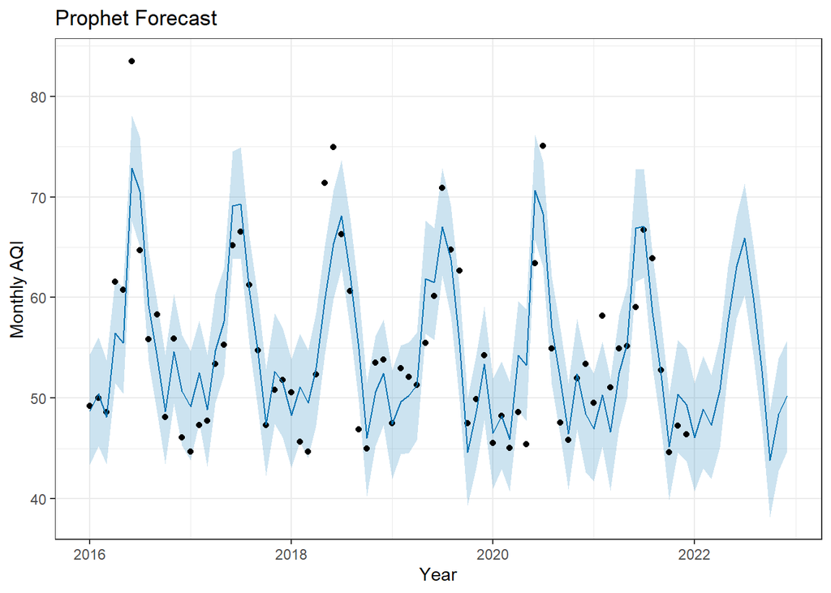

```r
#As monthly data, disabling weekly and daily seasonality
orig_model2 = prophet::prophet(AQIdata2_train,weekly.seasonality=FALSE,daily.seasonality=FALSE)

orig_future2 = make_future_dataframe(orig_model2,periods = 12, freq= 'month') # Create future dataframe for predictions

orig_forecast2 = predict(orig_model2,orig_future2) # Get forecast

plot(orig_model2, orig_forecast2)+
  ylab("Monthly AQI")+
  xlab("Year")+
  theme_bw() +
  ggtitle("Prophet Forecast")
```

```r
#ggplot() +
#  geom_point(aes(AQIdata2$ds,AQIdata2$y),colour = 'black') +
#  geom_line(aes(as.Date(orig_forecast2$ds),orig_forecast2$yhat),colour = 'blue')
```

**Daily AQI**

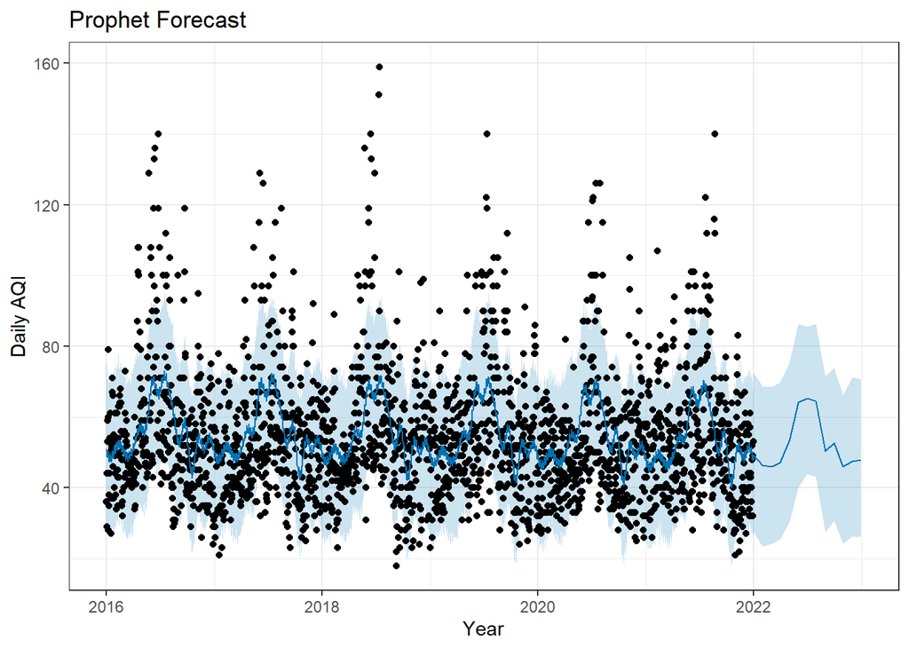

```r
#For daily data, disabling daily seasonality
orig_model1 = prophet::prophet(AQIdata1_train,daily.seasonality = FALSE)

orig_future1 = make_future_dataframe(orig_model1,periods = 12, freq= 'month') # Create future dataframe for predictions

orig_forecast1 = predict(orig_model1,orig_future1) # Get forecast

plot(orig_model1, orig_forecast1)+
  ylab("Daily AQI")+
  xlab("Year")+
  theme_bw() +
  ggtitle("Prophet Forecast")
```

#### Section 2. Prophet Decomposition

The default values of trend growth as “linear” seems alright we don’t see AQI values varying much across years and “additive” yearly seasonality seems alright as AQI seasonality doesn’t have lot of variation across time

**Monthly AQI**

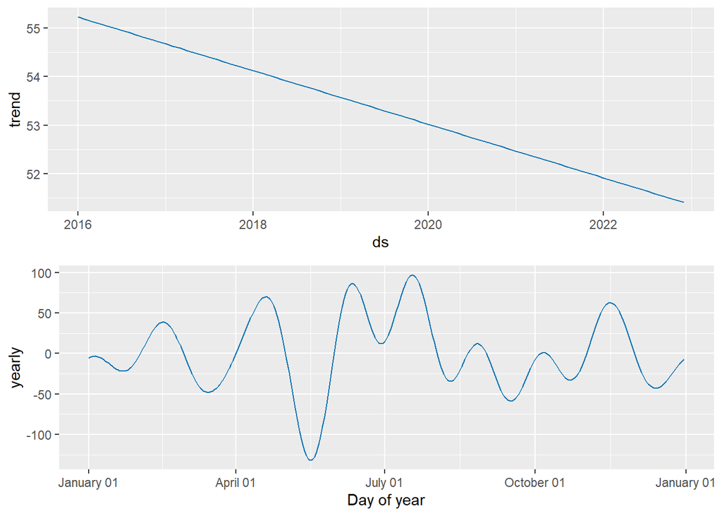

```r
orig_model2 = prophet::prophet(AQIdata2_train,
                               growth = "linear",
                               seasonality.mode = "additive",
                               weekly.seasonality=FALSE,daily.seasonality=FALSE)

orig_future2 = make_future_dataframe(orig_model2,periods = 12, freq= 'month')

orig_forecast2 = predict(orig_model2,orig_future2) # Get forecast
prophet_plot_components(orig_model2,orig_forecast2)
```

**Daily AQI**

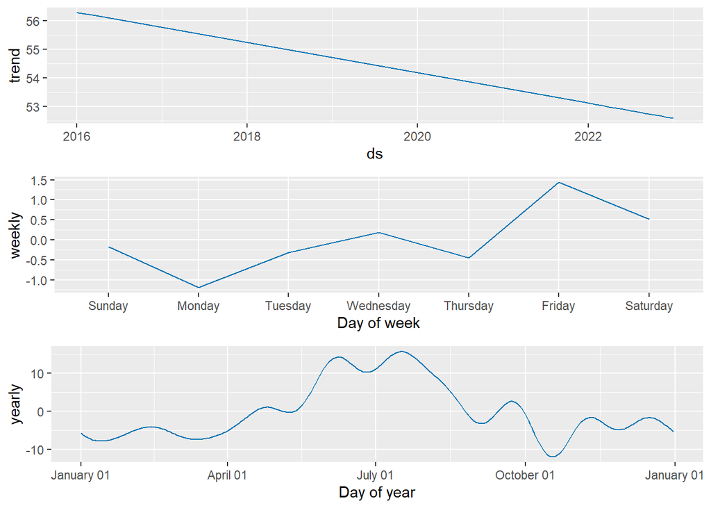

```r
orig_model1 = prophet::prophet(AQIdata1_train,
                               growth = "linear",
                               seasonality.mode = "additive",
                               daily.seasonality=FALSE)

orig_future1 = make_future_dataframe(orig_model1,periods = 12, freq= 'month')

orig_forecast1 = predict(orig_model1,orig_future1) # Get forecast
prophet_plot_components(orig_model1,orig_forecast1)
```

#### Plotting Changepoints

The number of changepoints considered by default is 25 (n.changepoints = 25), we don’t observe any changepoints being detected as the AQI data is mean stationary across years

**Monthly AQI**

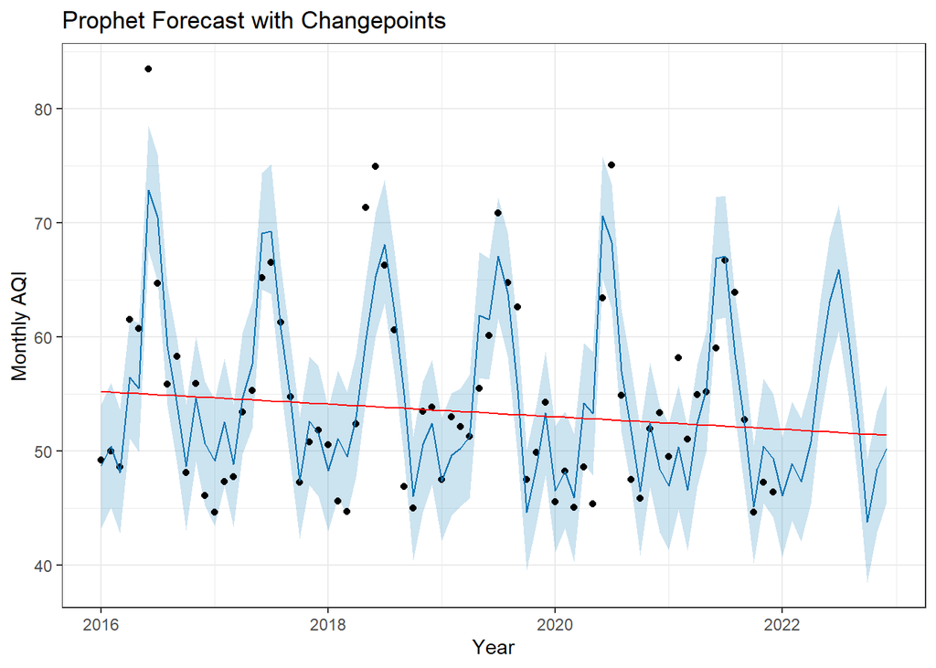

```r
plot(orig_model2,orig_forecast2)+
  add_changepoints_to_plot(orig_model2)+
  theme_bw()+
  xlab("Year")+
  ylab("Monthly AQI")+
  ggtitle("Prophet Forecast with Changepoints")
```

**Daily AQI**

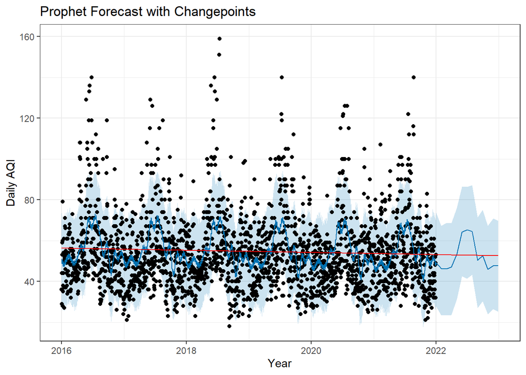

```r
plot(orig_model1,orig_forecast1)+
  add_changepoints_to_plot(orig_model1)+
  theme_bw()+
  xlab("Year")+
  ylab("Daily AQI")+
  ggtitle("Prophet Forecast with Changepoints")
```

We notice that even by increasing the #changepoints, there are no changepoints detected as expected.

**Monthly AQI**

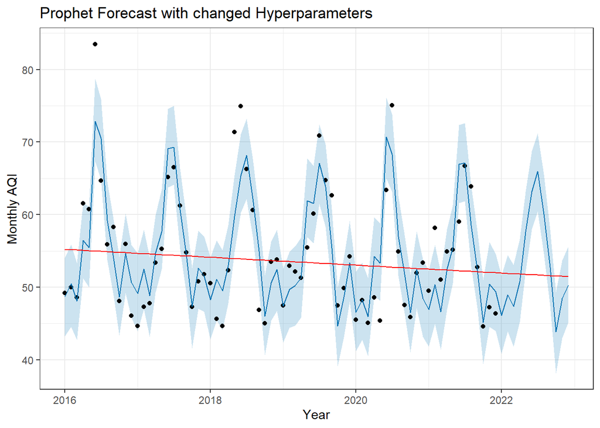

```r
# Increasing the Number of Changepoints

model = prophet::prophet(AQIdata2_train,n.changepoints = 50,
                         weekly.seasonality=FALSE,daily.seasonality=FALSE)

forecast = predict(model,orig_future2)

plot(model,forecast)+
  add_changepoints_to_plot(model)+
  theme_bw()+
  xlab("Year")+
  ylab("Monthly AQI")+
  ggtitle("Prophet Forecast with changed Hyperparameters")
```

**Daily AQI**

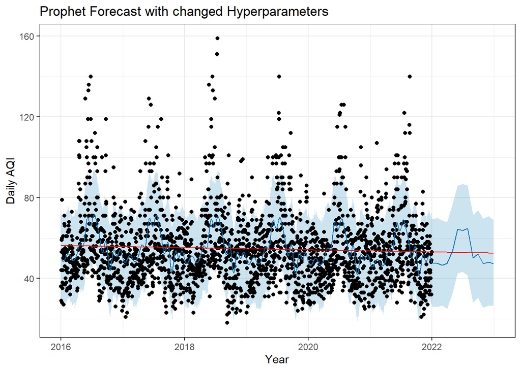

```r
# Increasing the Number of Changepoints

model = prophet::prophet(AQIdata1_train,n.changepoints = 50,
                         weekly.seasonality=FALSE,daily.seasonality=FALSE)

forecast = predict(model,orig_future1)

plot(model,forecast)+
  add_changepoints_to_plot(model)+
  theme_bw()+
  xlab("Year")+
  ylab("Daily AQI")+
  ggtitle("Prophet Forecast with changed Hyperparameters")
```

#### Section 3. Analyzing effect of Seasonality and Holidays

1. The component plots for additive and multiplicative seasonality do not have much difference in the components.

**Monthly AQI - Additive Seasonality**

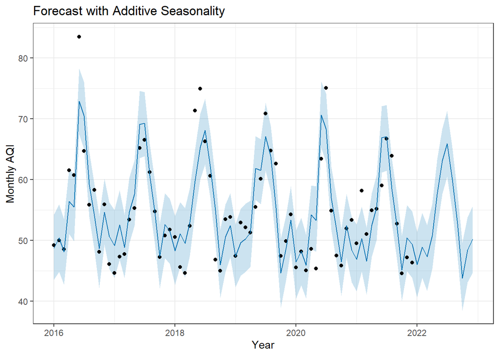

```r
additive_m = prophet::prophet(AQIdata2_train,seasonality.mode = 'additive',
                            weekly.seasonality=FALSE,daily.seasonality=FALSE)
add_fcst = predict(additive_m,orig_future2)

plot(additive_m,add_fcst)+
  theme_bw()+
  xlab("Year")+
  ylab("Monthly AQI")+
  ggtitle("Forecast with Additive Seasonality")
```

**Components**

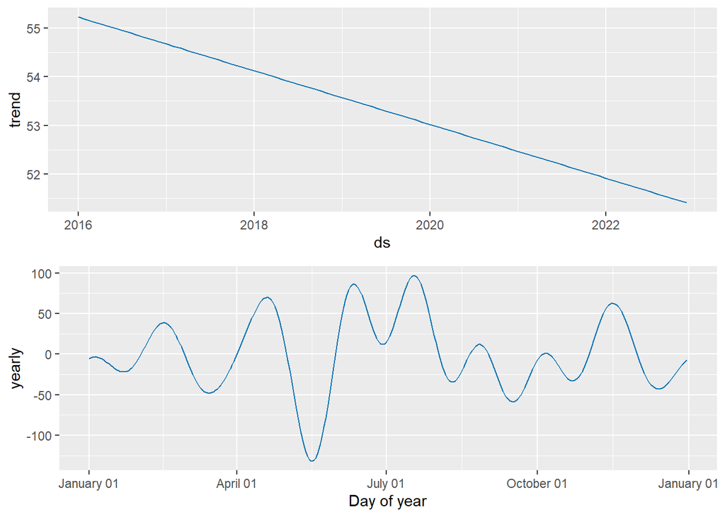

```r
prophet_plot_components(additive_m,add_fcst)
```

**Monthly AQI - Multiplicative Seasonality**

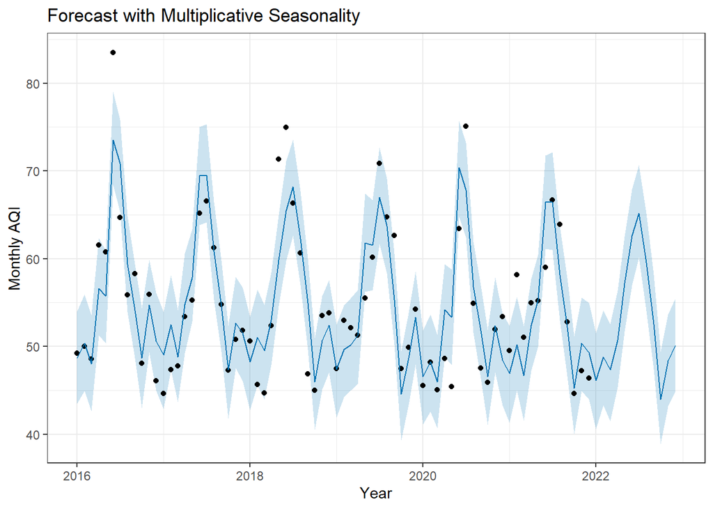

```r
multi_m = prophet::prophet(AQIdata2_train,seasonality.mode = 'multiplicative',
                         weekly.seasonality=FALSE,daily.seasonality=FALSE)
multi_fcst = predict(multi_m,orig_future2)

plot(multi_m,multi_fcst)+
  theme_bw()+
  xlab("Year")+
  ylab("Monthly AQI")+
  ggtitle("Forecast with Multiplicative Seasonality")
```

**Components**

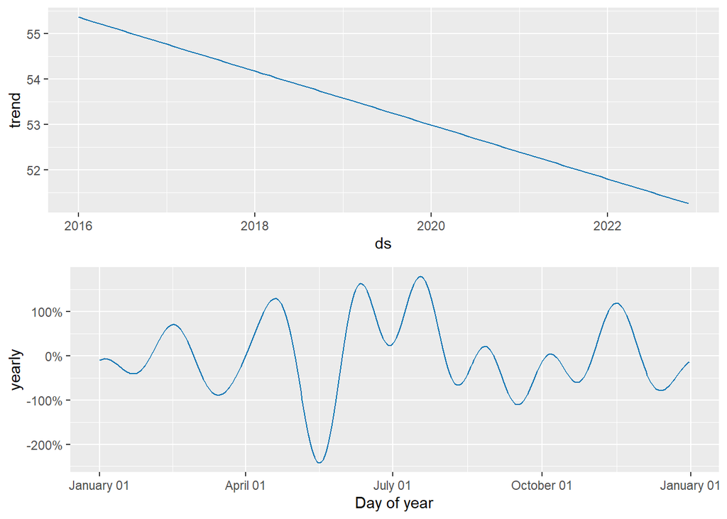

```r
prophet_plot_components(multi_m,multi_fcst)
```

**Daily AQI - Additive Seasonality**

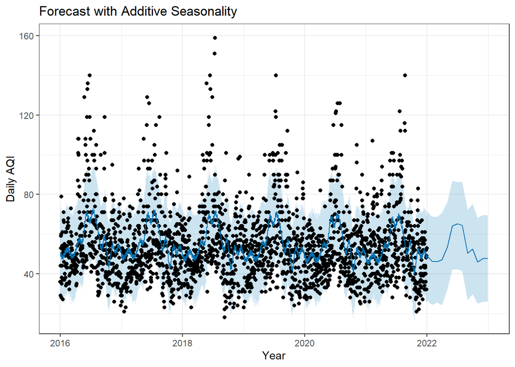

```r
additive_d = prophet::prophet(AQIdata1_train,seasonality.mode = 'additive',
                            daily.seasonality=FALSE)
add_fcst = predict(additive_d,orig_future1)

plot(additive_d,add_fcst)+
  theme_bw()+
  xlab("Year")+
  ylab("Daily AQI")+
  ggtitle("Forecast with Additive Seasonality")
```

**Components**

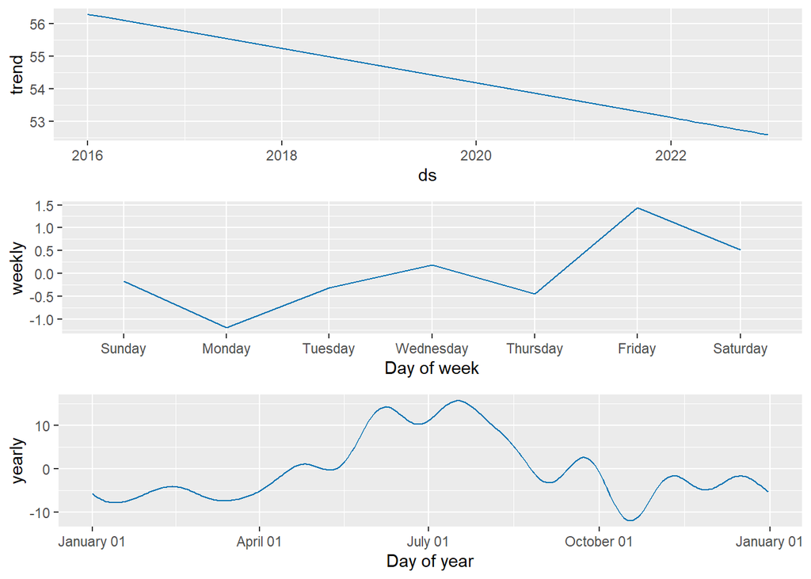

```r
prophet_plot_components(additive_d,add_fcst)
```

**Daily AQI - Multiplicative Seasonality**

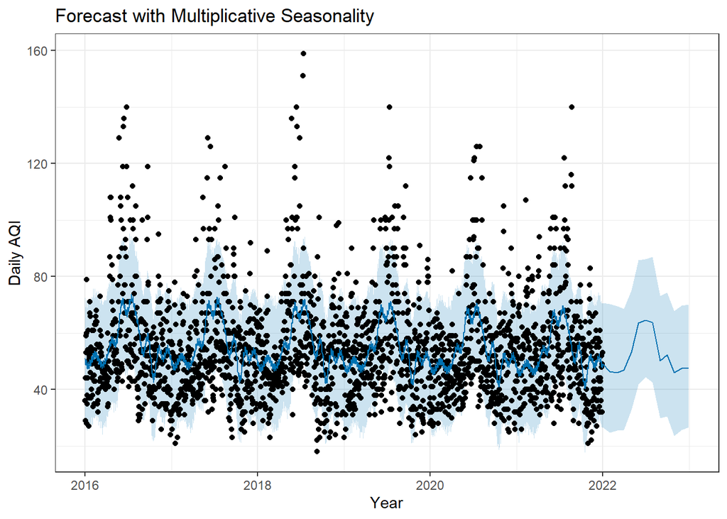

```r
multi_d = prophet::prophet(AQIdata1_train,seasonality.mode = 'multiplicative',
                         daily.seasonality=FALSE)
multi_fcst = predict(multi_d,orig_future1)

plot(multi_d,multi_fcst)+
  theme_bw()+
  xlab("Year")+
  ylab("Daily AQI")+
  ggtitle("Forecast with Multiplicative Seasonality")
```

**Components**

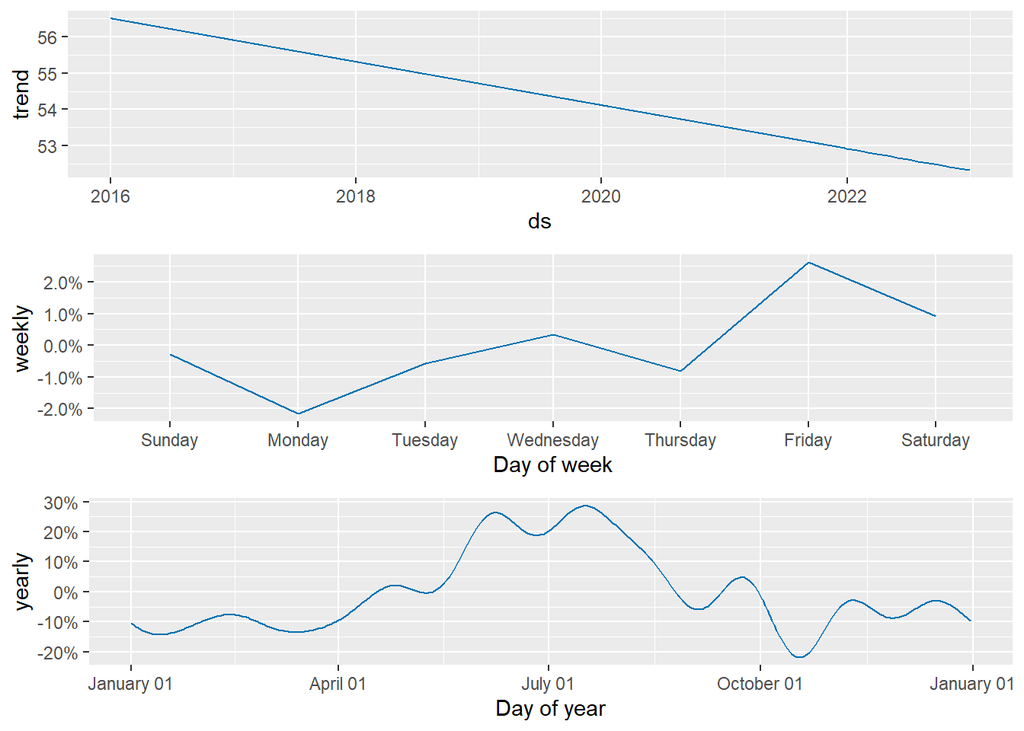

```r
prophet_plot_components(multi_d,multi_fcst)
```

2. Holiday Data Incorporation for Daily AQI

Independence and New years eve seems to have an impact on AQI, this could be due to celebration by fireworks

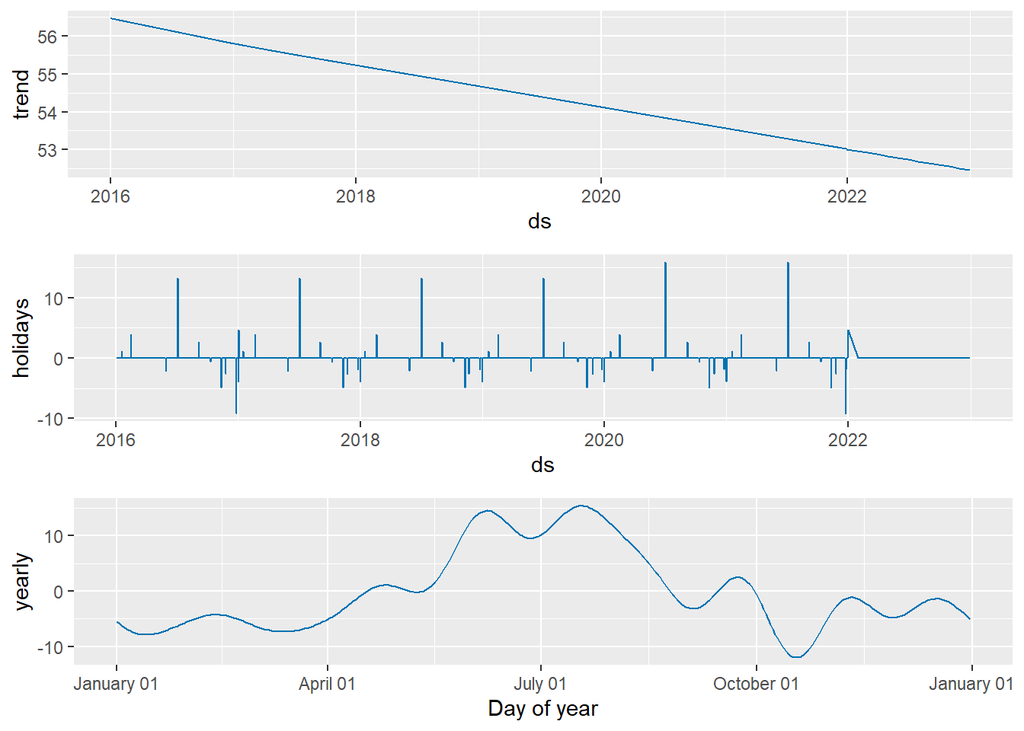

```r
model_holiday = prophet::prophet(AQIdata1_train,fit=FALSE, seasonality.mode = 'additive',
                                 weekly.seasonality=FALSE,daily.seasonality=FALSE)
model_holiday = add_country_holidays(model_holiday,country_name = 'US')
model_holiday = fit.prophet(model_holiday,AQIdata1_train)
forecast_holiday = predict(model_holiday,orig_future1)
prophet_plot_components(model_holiday,forecast_holiday)
```

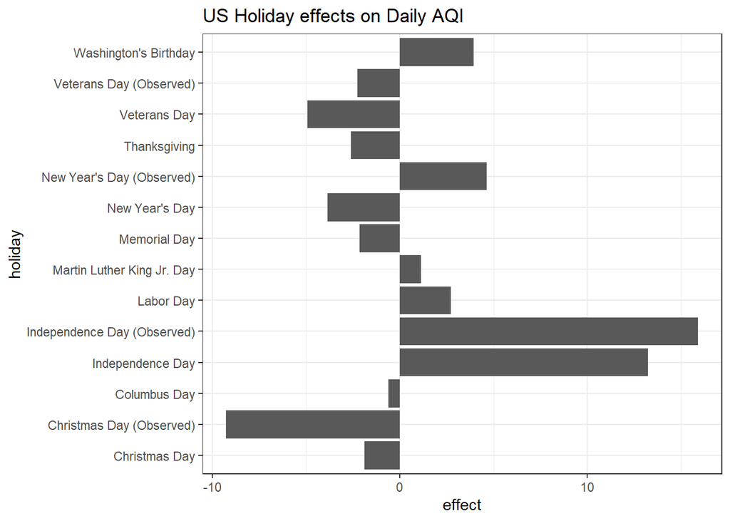

```r
forecast_holiday %>%
  filter(holidays != 0) %>%
  dplyr::select(-ds:-additive_terms_upper, -holidays:-holidays_upper, -contains("upper"), -contains("lower")) %>%
  mutate_all(~ if_else(. == 0, as.numeric(NA), .)) %>%
  summarize_if(is.numeric, ~ max(., na.rm = T)) %>%
  pivot_longer(
    cols = `Christmas Day`:`Washington's Birthday`,
    names_to = 'holiday',
    values_to = 'effect'
  ) %>%
ggplot() +
  geom_col(aes(effect,holiday))+
  theme_bw()+
  ggtitle("US Holiday effects on Daily AQI")
```

#### Section 4. Use cross-validation to assess performance of the model for different hyperparameters

Choosing additive yearly seasonality for Monthly AQI and additive yearly, weekly seasonality for Daily AQI.

Using 36 months data from 2016 to 2018 as my “initial” training data and keep adding next 3 months “period” to my data for next iterations. “horizon” is 12 months for which it will forecast

**Monthly AQI**

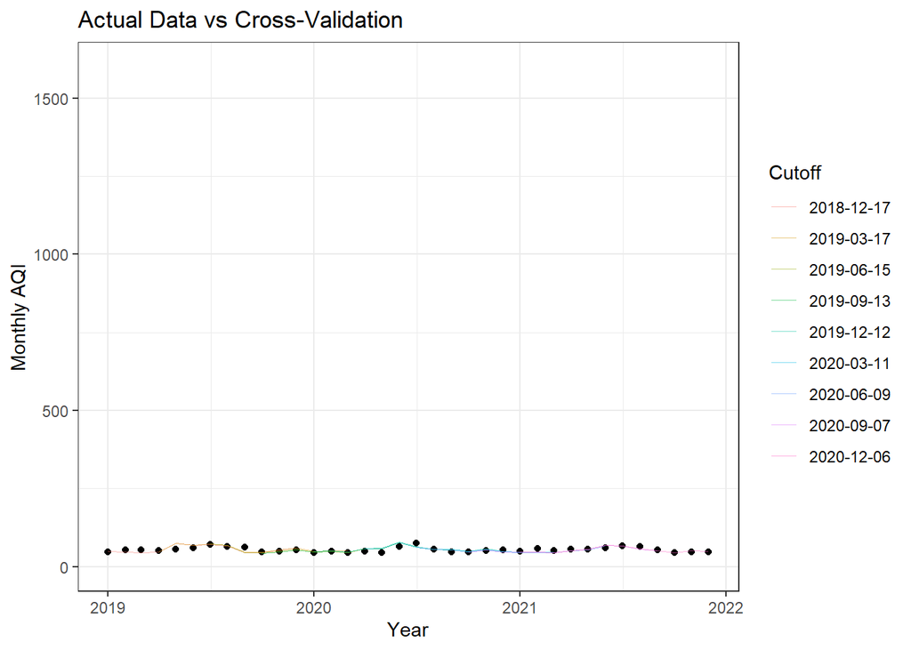

```r
df.cv <- cross_validation(additive_m, initial = 36*30, horizon = 12*30,period = 3*30, units = 'days')

df.cv %>%
  ggplot()+
  geom_point(aes(ds,y)) +
  geom_line(aes(ds,yhat,color=factor(cutoff)),size=0.01, alpha = 0.5)+
  theme_bw()+
  xlab("Year")+
  ylab("Monthly AQI")+
  scale_color_discrete(name = 'Cutoff')+
  ylim(0,1600)+
  ggtitle("Actual Data vs Cross-Validation")
```

**Daily AQI**

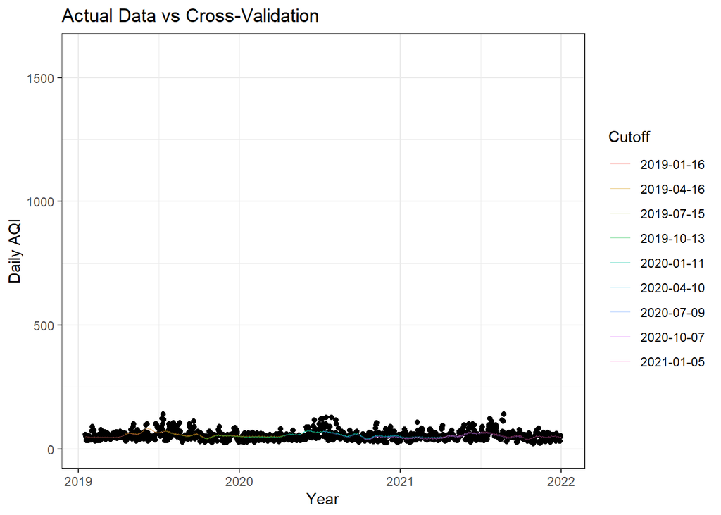

```r
df.cv1 <- cross_validation(additive_d, initial = 36*30, horizon = 12*30,period = 3*30, units = 'days')

df.cv1 %>%
  ggplot()+
  geom_point(aes(ds,y)) +
  geom_line(aes(ds,yhat,color=factor(cutoff)),size=0.01, alpha = 0.5)+
  theme_bw()+
  xlab("Year")+
  ylab("Daily AQI")+
  scale_color_discrete(name = 'Cutoff')+
  ylim(0,1600)+
  ggtitle("Actual Data vs Cross-Validation")
```

(i). Comparing models with additive and multiplicative seasonalities:-

We see no difference in RMSE for both the models.

**Monthly AQI**

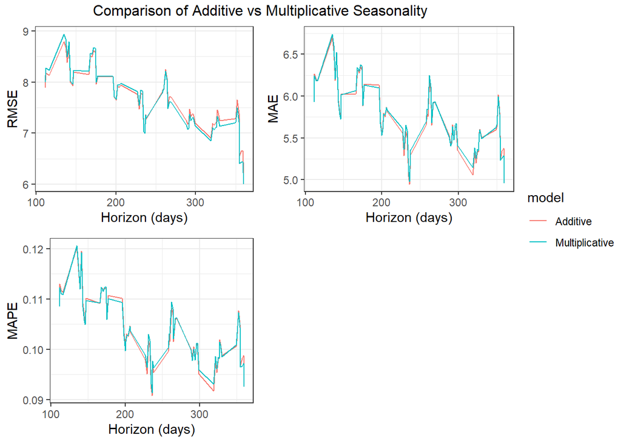

```r
library(lemon)
df_cv1 <- cross_validation(additive_m,initial = 36*30, horizon = 12*30,period = 3*30, units = 'days')
metrics1 = performance_metrics(df_cv1, rolling_window = 0.3) %>%
  mutate(model = 'Additive')

df_cv2 <- cross_validation(multi_m, initial = 36*30, horizon = 12*30,period = 3*30, units = 'days')
metrics2 = performance_metrics(df_cv2, rolling_window = 0.3) %>%
  mutate(model = "Multiplicative")


g1=metrics1 %>%
bind_rows(metrics2) %>%
ggplot()+
geom_line(aes(horizon,rmse,color=model))+
  theme_bw()+
  xlab("Horizon (days)")+
  ylab("RMSE")

g2 = metrics1 %>%
bind_rows(metrics2) %>%
ggplot()+
geom_line(aes(horizon,mae,color=model))+
  theme_bw()+
  xlab("Horizon (days)")+
  ylab("MAE")

g3 = metrics1 %>%
bind_rows(metrics2) %>%
ggplot()+
geom_line(aes(horizon,mape,color=model))+
  theme_bw()+
  xlab("Horizon (days)")+
  ylab("MAPE")

grid_arrange_shared_legend(g1, g2, g3, ncol = 2, nrow = 2, position='right', top = "Comparison of Additive vs Multiplicative Seasonality")
```

**Daily AQI**

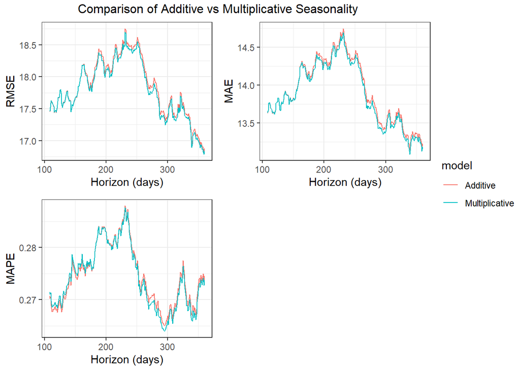

```r
library(lemon)
df_cv1 <- cross_validation(additive_d,initial = 36*30, horizon = 12*30,period = 3*30, units = 'days')
metrics1 = performance_metrics(df_cv1, rolling_window = 0.3) %>%
  mutate(model = 'Additive')

df_cv2 <- cross_validation(multi_d, initial = 36*30, horizon = 12*30,period = 3*30, units = 'days')
metrics2 = performance_metrics(df_cv2, rolling_window = 0.3) %>%
  mutate(model = "Multiplicative")


g1=metrics1 %>%
bind_rows(metrics2) %>%
ggplot()+
geom_line(aes(horizon,rmse,color=model))+
  theme_bw()+
  xlab("Horizon (days)")+
  ylab("RMSE")

g2 = metrics1 %>%
bind_rows(metrics2) %>%
ggplot()+
geom_line(aes(horizon,mae,color=model))+
  theme_bw()+
  xlab("Horizon (days)")+
  ylab("MAE")

g3 = metrics1 %>%
bind_rows(metrics2) %>%
ggplot()+
geom_line(aes(horizon,mape,color=model))+
  theme_bw()+
  xlab("Horizon (days)")+
  ylab("MAPE")

grid_arrange_shared_legend(g1, g2, g3, ncol = 2, nrow = 2, position='right', top = "Comparison of Additive vs Multiplicative Seasonality")
```

(ii). Comparing models with linear and logistic growth:-

For Monthly AQI : Linear seems to have higher RMSE initially for ~3 months forecast, but seems to do better than logistic post forecast for more than 3 months.

For Daily AQI: Logisitic trend seems to do better than linear trend

**Monthly AQI**

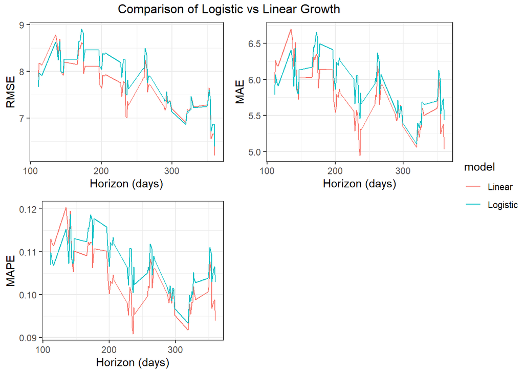

```r
AQIdata2_train_log <- AQIdata2_train
AQIdata2_train_log$floor = 30
AQIdata2_train_log$cap = 90
logistic_model = prophet::prophet(AQIdata2_train_log, growth= 'logistic')
df_cv3 <- cross_validation(logistic_model, initial = 36*30, horizon = 12*30,period = 3*30, units = 'days')
metrics3 = performance_metrics(df_cv3, rolling_window = 0.3) %>%
  mutate(model = 'Logistic')


linear_mod = prophet::prophet(AQIdata2_train, growth= 'linear')
df_cv4 <- cross_validation(linear_mod, initial = 36*30, horizon = 12*30,period = 3*30, units = 'days')
metrics4 = performance_metrics(df_cv4, rolling_window = 0.3) %>%
  mutate(model = "Linear")


g4=metrics3 %>%
bind_rows(metrics4) %>%
ggplot()+
geom_line(aes(horizon,rmse,color=model))+
  theme_bw()+
  xlab("Horizon (days)")+
  ylab("RMSE")

g5 = metrics3 %>%
bind_rows(metrics4) %>%
ggplot()+
geom_line(aes(horizon,mae,color=model))+
  theme_bw()+
  xlab("Horizon (days)")+
  ylab("MAE")

g6 = metrics3 %>%
bind_rows(metrics4) %>%
ggplot()+
geom_line(aes(horizon,mape,color=model))+
  theme_bw()+
  xlab("Horizon (days)")+
  ylab("MAPE")

grid_arrange_shared_legend(g4, g5, g6, ncol = 2, nrow = 2, position='right', top = "Comparison of Logistic vs Linear Growth")
```

**Daily AQI**

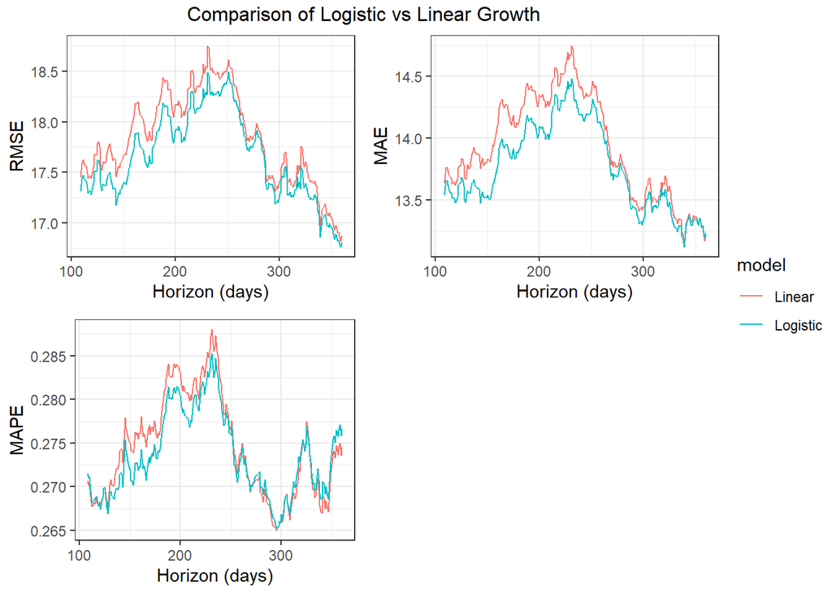

```r
AQIdata1_train_log <- AQIdata1_train
AQIdata1_train_log$floor = 30
AQIdata1_train_log$cap = 90
logistic_model = prophet::prophet(AQIdata1_train_log, growth= 'logistic')
df_cv3 <- cross_validation(logistic_model, initial = 36*30, horizon = 12*30,period = 3*30, units = 'days')
metrics3 = performance_metrics(df_cv3, rolling_window = 0.3) %>%
  mutate(model = 'Logistic')


linear_mod = prophet::prophet(AQIdata1_train, growth= 'linear')
df_cv4 <- cross_validation(linear_mod, initial = 36*30, horizon = 12*30,period = 3*30, units = 'days')
metrics4 = performance_metrics(df_cv4, rolling_window = 0.3) %>%
  mutate(model = "Linear")


g4=metrics3 %>%
bind_rows(metrics4) %>%
ggplot()+
geom_line(aes(horizon,rmse,color=model))+
  theme_bw()+
  xlab("Horizon (days)")+
  ylab("RMSE")

g5 = metrics3 %>%
bind_rows(metrics4) %>%
ggplot()+
geom_line(aes(horizon,mae,color=model))+
  theme_bw()+
  xlab("Horizon (days)")+
  ylab("MAE")

g6 = metrics3 %>%
bind_rows(metrics4) %>%
ggplot()+
geom_line(aes(horizon,mape,color=model))+
  theme_bw()+
  xlab("Horizon (days)")+
  ylab("MAPE")

grid_arrange_shared_legend(g4, g5, g6, ncol = 2, nrow = 2, position='right', top = "Comparison of Logistic vs Linear Growth")
```

(iii). Comparing models with and without holidays:-

We see no difference in RMSE for both the models.

#### Daily AQI

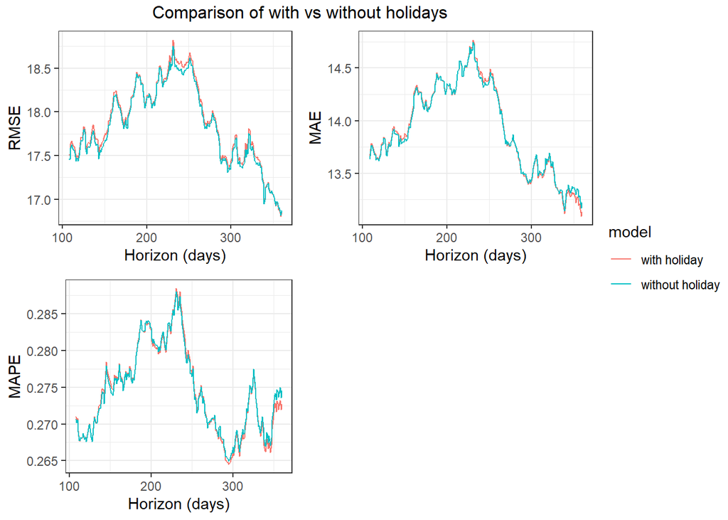

```r
df_cv5 <- cross_validation(model_holiday,  initial = 36*30, horizon = 12*30,period = 3*30, units = 'days')
metrics3 = performance_metrics(df_cv5, rolling_window = 0.3) %>%
  mutate(model = 'with holiday')


df_cv6 <- cross_validation(additive_d, initial = 36*30, horizon = 12*30,period = 3*30, units = 'days')
metrics4 = performance_metrics(df_cv6, rolling_window = 0.3) %>%
  mutate(model = "without holiday")


g4=metrics3 %>%
bind_rows(metrics4) %>%
ggplot()+
geom_line(aes(horizon,rmse,color=model))+
  theme_bw()+
  xlab("Horizon (days)")+
  ylab("RMSE")

g5 = metrics3 %>%
bind_rows(metrics4) %>%
ggplot()+
geom_line(aes(horizon,mae,color=model))+
  theme_bw()+
  xlab("Horizon (days)")+
  ylab("MAE")

g6 = metrics3 %>%
bind_rows(metrics4) %>%
ggplot()+
geom_line(aes(horizon,mape,color=model))+
  theme_bw()+
  xlab("Horizon (days)")+
  ylab("MAPE")

grid_arrange_shared_legend(g4, g5, g6, ncol = 2, nrow = 2, position='right', top = "Comparison of with vs without holidays")
```

#### Forecasting for 2023 using the best model we got from cross validation

For Monthly AQI: with linear growth and additive seasonality For Daily AQI: with logistic growth and additive seasonality

Yes, the forecast make sense given recent history, with the AQI values being low in the initial months of the year and peaking during the summer month - June

**Monthly AQI**

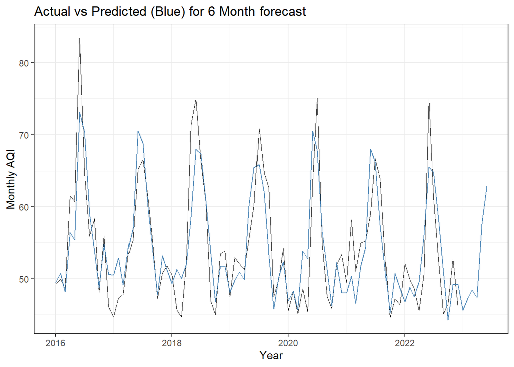

```r
best_fit_model = prophet::prophet(AQIdata2, growth = 'linear', seasonality.mode = 'additive',
                                  weekly.seasonality=FALSE,
                                  daily.seasonality=FALSE)

best_fit_future_month = make_future_dataframe(best_fit_model,periods = 6, freq= 'months') # Create future dataframe for predictions

best_fit_forecast_month = predict(best_fit_model,best_fit_future_month) # Get forecast

ggplot()+
geom_line(aes(as.Date(AQIdata2$ds),AQIdata2$y), size = 0.3)+
geom_line(aes(as.Date(best_fit_forecast_month$ds),best_fit_forecast_month$yhat),color='steel blue', alpha = 0.9)+
theme_bw()+
ylab('Monthly AQI')+
xlab('Year')+
  ggtitle("Actual vs Predicted (Blue) for 6 Month forecast")
```

**Daily AQI**

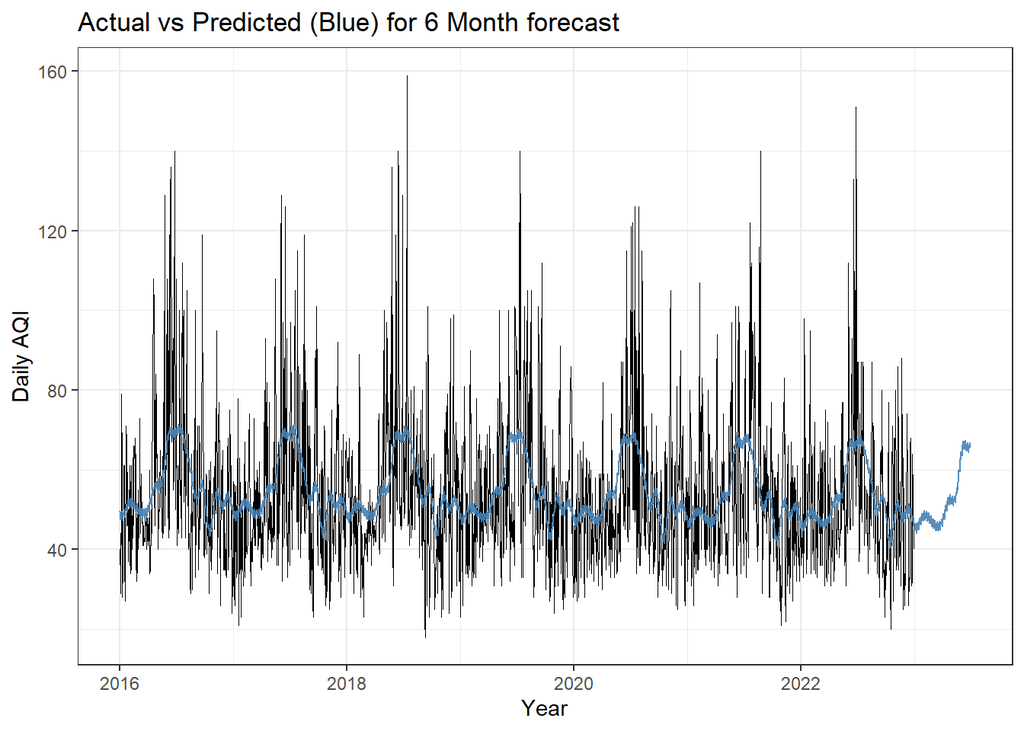

```r
AQIdata1_log <- AQIdata1
AQIdata1_log$floor = 0
AQIdata1_log$cap = 200
best_fit_model1 = prophet::prophet(AQIdata1_log, growth = 'logistic'
                                   , seasonality.mode = 'additive',
                                  daily.seasonality=FALSE)

best_fit_future_month1 = make_future_dataframe(best_fit_model1,periods = 182, freq= 'day') # Create future dataframe for predictions
best_fit_future_month1$floor = 0
best_fit_future_month1$cap = 200

best_fit_forecast_month1 = predict(best_fit_model1,best_fit_future_month1) # Get forecast

ggplot()+
geom_line(aes(as.Date(AQIdata1$ds),AQIdata1$y), size = 0.3)+
geom_line(aes(as.Date(best_fit_forecast_month1$ds),best_fit_forecast_month1$yhat),color='steel blue', alpha = 0.9)+
theme_bw()+
ylab('Daily AQI')+
xlab('Year')+
  ggtitle("Actual vs Predicted (Blue) for 6 Month forecast")
```